# XGBoost

Jack Julian and Seth Grace

2025-11-08

# Read in the data

The following dataset will be used to predict `loan_default`.

```r
holdout.df=readRDS("M:/MSBA/ISA 591/Holdout_cleaned.RDS")
df=readRDS("M:/MSBA/ISA 591/EDA_cleaned.RDS")
# target smaller sample size, e.g., 5,000 rows total
set.seed(123)
train.smaller <- df %>%
  dplyr::sample_n(25000)


table(train.smaller$loan_default)
```

```
##
##    No   Yes
## 20128  4872
```

We elected to downsample to 25,000 observations due to issues with computational power. By reducing to 25,000 observations we increase the bias and possibly the variance as well. It is a potentially risky move however, given our processing power we elected to move forward with it.

# XG Boost Model

```r
cores=parallel::detectCores()
cores
```

```
## [1] 64
```

We used parallel processing to use multiple cores so that we could speed up the model training.

```r
# Here we are using cores-1, but you can adjust this based on your machine
cl <- parallel::makeCluster(cores-1)  # Set CPU cores for parallel execution
registerDoParallel(cl)  # Register parallel backend


library(caret)
set.seed(1)

# CV settings (same as RF)
cv_control <- trainControl(
  method = "cv",
  number = 5,
  classProbs = TRUE,
  summaryFunction = twoClassSummary
)

# XGBoost model (baseline)
xgb_base <- train(
  loan_default ~ .,
  data = train.smaller,
  method = "xgbTree",
  trControl = cv_control,
  tuneLength = 5,      # just like class notes
  metric = "ROC"
)

xgb_base
```

```
## eXtreme Gradient Boosting
##
## 25000 samples
##    39 predictor
##     2 classes: 'No', 'Yes'
##
## No pre-processing
## Resampling: Cross-Validated (5 fold)
## Summary of sample sizes: 20001, 20001, 20000, 19999, 19999
## Resampling results across tuning parameters:
##
##   eta  max_depth  colsample_bytree  subsample  nrounds  ROC        Sens
##   0.3  1          0.6               0.500       50      0.7345304  0.9943364
##   0.3  1          0.6               0.500      100      0.7388395  0.9883744
##   0.3  1          0.6               0.500      150      0.7381440  0.9853936
##   0.3  1          0.6               0.500      200      0.7380672  0.9830586
##   0.3  1          0.6               0.500      250      0.7377124  0.9822636
##   0.3  1          0.6               0.625       50      0.7338406  0.9959262
##   0.3  1          0.6               0.625      100      0.7366068  0.9891197
##   0.3  1          0.6               0.625      150      0.7372649  0.9861387
##   0.3  1          0.6               0.625      200      0.7379182  0.9843005
##   0.3  1          0.6               0.625      250      0.7375332  0.9837045
##   0.3  1          0.6               0.750       50      0.7336729  0.9965720
##   0.3  1          0.6               0.750      100      0.7372027  0.9897655
##   0.3  1          0.6               0.750      150      0.7378042  0.9864865
##   0.3  1          0.6               0.750      200      0.7383922  0.9854929
##   0.3  1          0.6               0.750      250      0.7384899  0.9844496
##   0.3  1          0.6               0.875       50      0.7339533  0.9975656
##   0.3  1          0.6               0.875      100      0.7374203  0.9907095
##   0.3  1          0.6               0.875      150      0.7382649  0.9876790
##   0.3  1          0.6               0.875      200      0.7381958  0.9862382
##   0.3  1          0.6               0.875      250      0.7380725  0.9852445
##   0.3  1          0.6               1.000       50      0.7338620  0.9978140
##   0.3  1          0.6               1.000      100      0.7377078  0.9920510
##   0.3  1          0.6               1.000      150      0.7382247  0.9898153
##   0.3  1          0.6               1.000      200      0.7387919  0.9884242
##   0.3  1          0.6               1.000      250      0.7384922  0.9871821
##   0.3  1          0.8               0.500       50      0.7334702  0.9953795
##   0.3  1          0.8               0.500      100      0.7374274  0.9884241
##   0.3  1          0.8               0.500      150      0.7366727  0.9857412
```

[output cut: 966 more lines]

```
##   0.22618754
##   0.23214174
##   0.17384784
##   0.19704544
##   0.20669405
##   0.21490486
##   0.22249734
##
## Tuning parameter 'gamma' was held constant at a value of 0
## Tuning
##  parameter 'min_child_weight' was held constant at a value of 1
## ROC was used to select the optimal model using the largest value.
## The final values used for the model were nrounds = 50, max_depth = 3, eta
##  = 0.3, gamma = 0, colsample_bytree = 0.6, min_child_weight = 1 and subsample
##  = 1.
```

```r
varImp(xgb_base)
```

```
## xgbTree variable importance
##
##   only 20 most important variables shown (out of 88)
##
##                                    Overall
## int_rate                           100.000
## debt_settlement_flagY               84.003
## term 60 months                      29.479
## issue_year                          27.944
## dti                                 18.258
## log_annual_inc                      16.231
## fico_range_avg                      15.790
## length_of_credit_line               14.807
## loan_amnt                            9.972
## issue_month                          7.679
## revol_util                           7.650
## emp_length_num                       6.055
## mort_acc                             5.534
## home_ownership_RENT                  3.869
## log_revol_bal                        3.620
## home_ownership_MORTGAGE              3.060
## total_acc                            2.233
## open_acc                             1.806
## inq_last_6mths                       1.784
## `verification_status_Not Verified`   1.132
```

The XGBoost model reveals that interest rate is by far the most critical predictor of loan default, with a variable importance score of 100, indicating that higher interest rates strongly correlate with increased default risk. The second most important factor is the debt settlement flag, scoring 84, which makes intuitive business sense as borrowers with previous debt settlement history represent significantly higher risk. Other key predictors include loan term length (60-month terms scoring 29.5 show much higher default rates than 36-month terms), the year the loan was issued (27.9, capturing economic conditions and changing lending standards), debt-to-income ratio (18.3, measuring borrowers' capacity to handle payments), log-transformed annual income (16.2), and average FICO score (15.8). These results suggest that the model is primarily driven by pricing risk and past financial distress indicators, providing clear guidance for future lending decisions.

▌

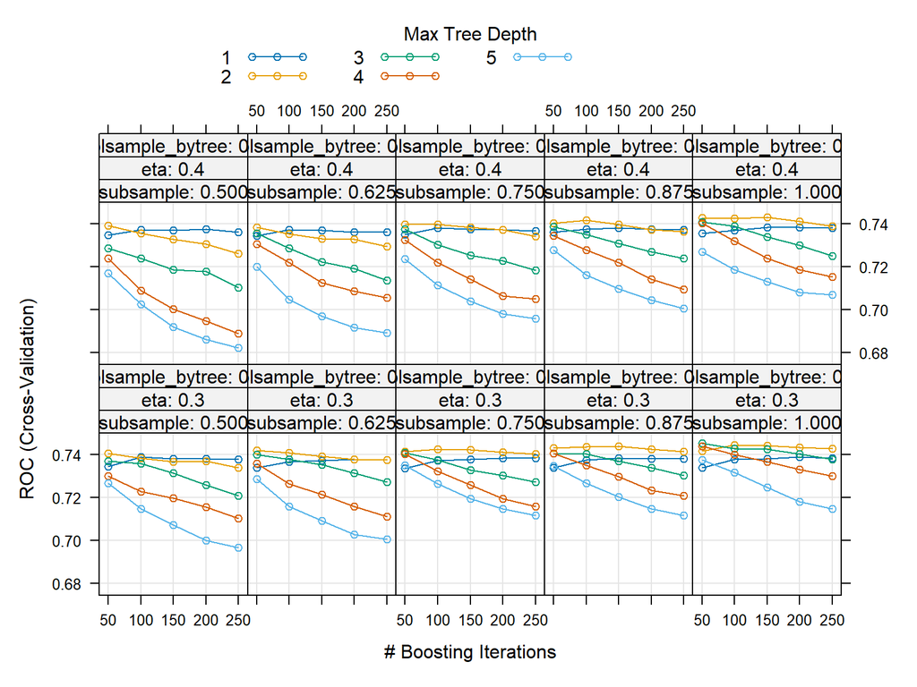

[figure not shown]

```r
plot(xgb_base)
```

```r
# Step 4: Stop Parallel Processing ----
stopCluster(cl)  # Shut down parallel cluster
registerDoSEQ()  # Reset to sequential processing
```

## XG Boost

```r
# Predicted class labels
xgb.pred.class <- predict(xgb_base, newdata = holdout.df)

# Predicted probabilities (for ROC / AUC)
xgb.pred.prob <- predict(xgb_base, newdata = holdout.df, type = "prob")[, "Yes"]

# Confusion Matrix
confusionMatrix(
  xgb.pred.class,
  holdout.df$loan_default,
  positive = "Yes"
)
```

```
## Confusion Matrix and Statistics
##
##           Reference
## Prediction    No   Yes
##        No  62722 13242
##        Yes   970  2299
##
##                Accuracy : 0.8206
##                  95% CI : (0.8179, 0.8233)
##     No Information Rate : 0.8039
##     P-Value [Acc > NIR] : < 2.2e-16
##
##                   Kappa : 0.1892
##
##  Mcnemar's Test P-Value : < 2.2e-16
##
##             Sensitivity : 0.14793
##             Specificity : 0.98477
##          Pos Pred Value : 0.70327
##          Neg Pred Value : 0.82568
##              Prevalence : 0.19614
##          Detection Rate : 0.02902
##    Detection Prevalence : 0.04126
##       Balanced Accuracy : 0.56635
##
##        'Positive' Class : Yes
##
```

```r
# --- Compute and print AUC ---
library(pROC)

roc_obj <- roc(holdout.df$loan_default, xgb.pred.prob, levels = c("No", "Yes"))
auc_value <- auc(roc_obj)
print(paste("AUC:", round(auc_value, 4)))
```

```
## [1] "AUC: 0.7453"
```

The confusion matrix reveals that while the XGBoost model achieves a solid overall accuracy of 82.06%, it struggles significantly with detecting actual loan defaults. The model has very low sensitivity (14.79%), meaning it only correctly identifies about 15% of borrowers who will actually default, missing 85% of true defaults (13,242 false negatives). However, it demonstrates excellent specificity (98.48%), correctly identifying 98.5% of borrowers who won't default with very few false alarms (only 970 false positives). The model's precision for default prediction is strong at 70.33%, meaning when it does predict a default, it's correct about 70% of the time. The AUC of 0.7453 indicates moderate discriminatory power, but the extremely low sensitivity suggests the model is too conservative in flagging potential defaults. From a business perspective, this means the model would miss most borrowers likely to default, potentially leading to significant financial losses, though it would avoid rejecting many good borrowers unnecessarily.

▌